# Assignment03

Dasha Djukic-Min

3/9/2022

## Access TEDS2016 dataset by importing it from Stata

```r
library("haven")
TEDS_2016<-read_dta("https://github.com/datageneration/home/blob/master/DataProgramming/data/TEDS_2016.dta?raw=true")
```

## Select only relevant variables to create a subset of the dataset (Tondu, female, DPP, age, income, edu, Taiwanes eand Econ_worse).

```r
TEDS_2016_subset <- subset(TEDS_2016, select = c("Tondu","female","DPP","age","income","edu","Taiwanese","Econ_worse"))
```

## Make sure the dependent variable Tondu is coded with right labels

```r
TEDS_2016_subset$Tondu<-as.numeric(TEDS_2016_subset$Tondu,labels=c("Unification now", "Status quo, unif. in future", "Status quo, decide later", "Status quo forever", "Status quo, indep. in future", "Independence now", "No response"))
```

## Multiple regression analysis

## Tondu refers to an attitude toward unification with mainland China.

```r
model1=lm(Tondu ~ age + income + edu,data=TEDS_2016_subset)
summary(model1)
```

```
##
## Call:
## lm(formula = Tondu ~ age + income + edu, data = TEDS_2016_subset)
##
## Residuals:
##     Min      1Q  Median      3Q     Max
## -3.7780 -1.1841 -0.4322  1.1079  5.4157
##
## Coefficients:
##              Estimate Std. Error t value Pr(>|t|)
## (Intercept)  5.302529   0.257369  20.603  < 2e-16 ***
## age         -0.004205   0.003194  -1.316   0.1882
## income      -0.031855   0.016357  -1.948   0.0516 .
## edu         -0.244608   0.037579  -6.509 9.96e-11 ***
## ---
## Signif. codes:  0 '***' 0.001 '**' 0.01 '*' 0.05 '.' 0.1 ' ' 1
##
## Residual standard error: 1.725 on 1676 degrees of freedom
##   (10 observations deleted due to missingness)
## Multiple R-squared:  0.04287,    Adjusted R-squared:  0.04115
## F-statistic: 25.02 on 3 and 1676 DF,  p-value: 7.771e-16
```

## Regplot

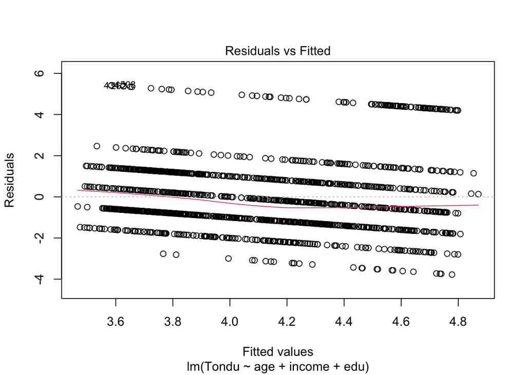

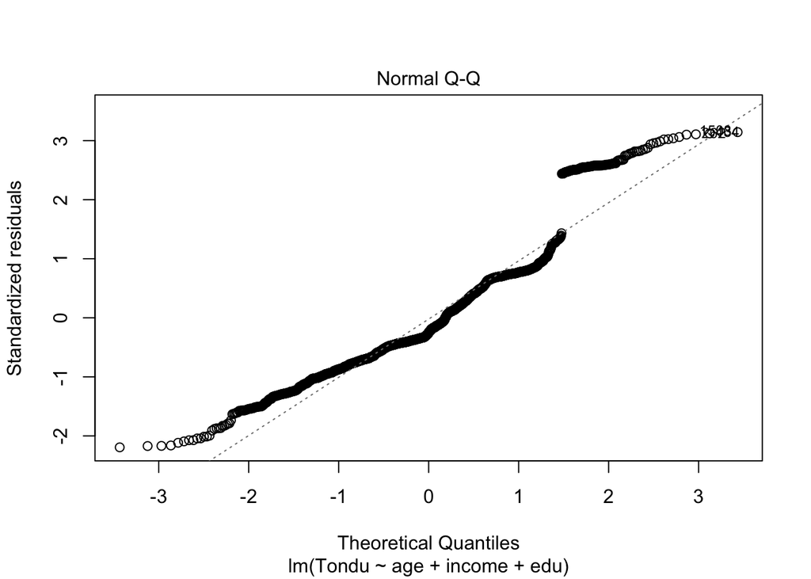

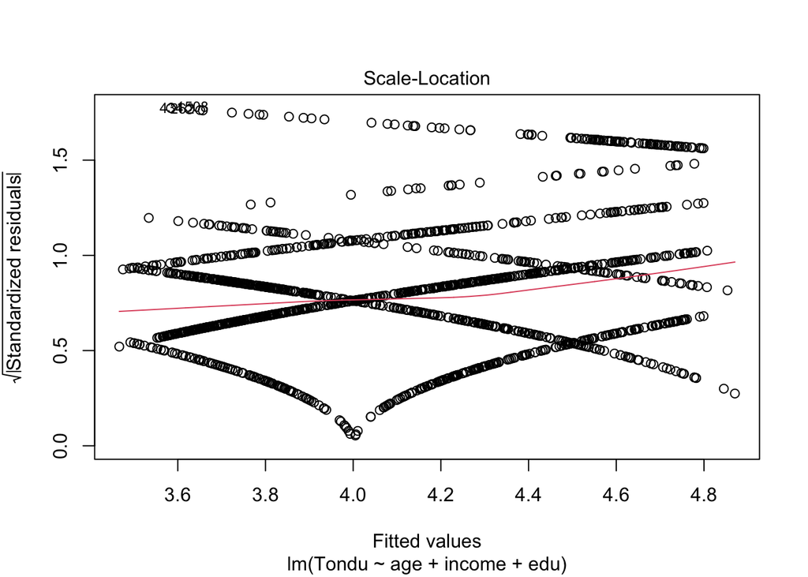

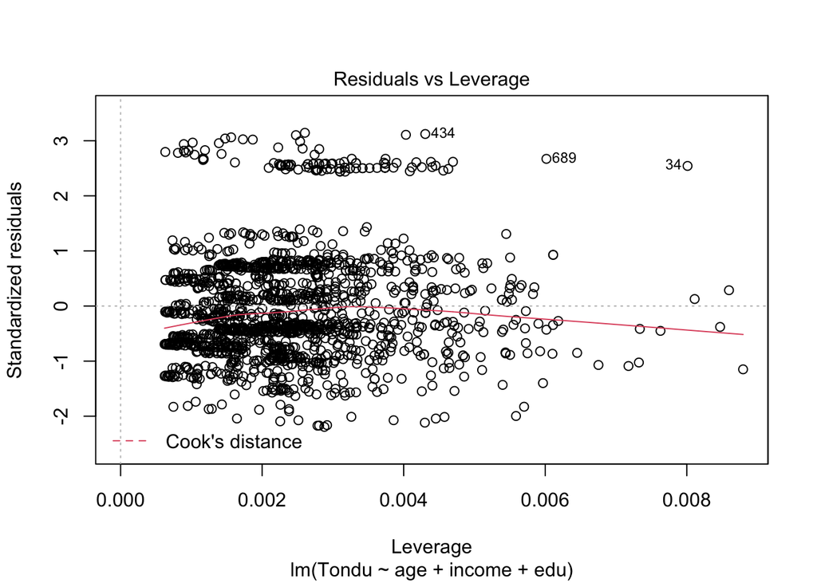

```r
(regplot= plot(lm(Tondu ~ age + income + edu, data = TEDS_2016_subset)))
```

## Steps to run a multinomial regression analysis: https://stats.oarc.ucla.edu/r/dae/multinomial-logistic-regression/

## First, we need to choose the level of our outcome that we wish to use as our baseline and specify this in the relevel function.

## To do so, reorganize the DV as unordered factors (and before that, define a new subset to use with this newly defined DV).

```r
TEDS_2016_subset1 <- subset(TEDS_2016, select = c("Tondu","female","DPP","age","income","edu","Taiwanese","Econ_worse"))
TEDS_2016_subset1$Tondu<-factor(TEDS_2016_subset$Tondu,labels=c("Unification now", "Status quo, unif. in future", "Status quo, decide later", "Status quo forever", "Status quo, indep. in future", "Independence now", "No response"))
TEDS_2016_subset1$Tondu1 <- relevel(factor(TEDS_2016_subset1$Tondu), ref = "Status quo forever")
```

## Then we run our model using multinom

```r
library(nnet)
model2 <- multinom(Tondu1 ~ age + income +edu, data = TEDS_2016_subset1)
summary(model2)
```

```
## Call:
## multinom(formula = Tondu1 ~ age + income + edu, data = TEDS_2016_subset1)
##
## Coefficients:
##                              (Intercept)         age       income        edu
## Unification now               -2.1549387  0.01010911 -0.063150287 -0.2394468
## Status quo, unif. in future   -2.8537017  0.02516931  0.024722292  0.2426497
## Status quo, decide later       0.9803362 -0.01942986  0.010187277  0.1323068
## Status quo, indep. in future   0.9225328 -0.03101966  0.003336138  0.1987447
## Independence now               1.9743202 -0.03678385 -0.077439043 -0.2882092
## No response                   -0.5399675  0.01876827 -0.065517089 -0.5604003
##
## Std. Errors:
##                              (Intercept)         age     income        edu
## Unification now                1.3202862 0.016403438 0.07947722 0.19072665
## Status quo, unif. in future    0.5834670 0.007075456 0.03605767 0.07944057
## Status quo, decide later       0.4367569 0.005491754 0.02754069 0.06292071
## Status quo, indep. in future   0.4777090 0.006058734 0.03017855 0.07014215
## Independence now               0.6862989 0.008950275 0.04397361 0.10342960
## No response                    0.7560652 0.009340697 0.04318008 0.11696422
##
## Residual Deviance: 5303.817
## AIC: 5351.817
```

## The multinom package does not include p-value calculation for the regression coefficients, so we calculate p-values using Wald tests (here z-tests).

```r
z <- summary(model2)$coefficients/summary(model2)$standard.errors
 p <- (1 - pnorm(abs(z), 0, 1)) * 2
```